# Comparisons over time and space

SNA Week 10

# CLASS NEXT TUESDAY FROM 10:45-11:45?

# Networks are often **dynamic**: they change over time

- Friendship in school classes.
- Evolution of policy networks.
- Co-sponsorship between legislators.
- Conflict in the international system.
- E-mail communication in an organization

# The approprtiate dyanmic model, depends on the nature of the process

1. Does the theoretical process have a continuous or discrete timing?
2. Can we expect simultaneous actions?
3. What is the time resolution of observations?
4. Do we observe time slices (e.g., international conflict) or are we making point observations (e.g., a policy network survey)?
5. Are the observational time units naturally given or artificially created?
6. Do edges have a duration or can they be considered events?

# Continuous-time or ordered sequence of events; no natural observational units:

Relational Event Model (REM)

# Continuous time, but discrete observation; edges have a duration:

1. Stochastic Actor-Oriented Model (SAOM)
2. Temporal Exponential Random Graph Model (TERGM)

# All other cases (simultaneous action can occur; discrete timing; long time periods between observations etc.):

Temporal Exponential Random Graph Model (TERGM)

# The TERGM

- time independence $\rightarrow$ Pooled ERGM (simplest version)
- ties (and non-ties) depend on previous ties $\rightarrow$ memory terms
  - autoregression
  - dyadic stability
  - edge innovation
  - edge loss
- more complex time dependence:
  - Single-period delayed reciprocity
  - Triadic closure over three time periods.
  - etc

# The cross-sectional ERGM

$$P(N, \theta) =
\frac
{exp(\mathbf{\theta}'\mathbf{h}(N))}
{\sum_{N^*\in\mathcal{N}}exp(\mathbf{\theta}'\mathbf{h}(N^*))}$$

- $N$ = the network
- $\mathbf{h}(N)$ = network statistics
- $\theta$ = coefficients
- $\sum_{N^*\in\mathcal{N}}exp(\mathbf{\theta'h}(N^*))$ = Normalizing constant

# The TERGM

Every network $N^t$ may depend on $K \in \{0, 1, \dots, T - 1\}$ previous (lagged) networks.

Probability of observing $N^t$:
$$P(N^t| N^{t - K}, \dots, N^{t - 1}, \theta) =
\frac
{exp(\mathbf{\theta}'\mathbf{h}(N^t, N^{t - 1}, \dots, N^{t - K}))}
{c(\theta, N^{t - K}, \dots, N^{t - 1})}$$

- Assumption: $K$ fully encompasses the dependencies of $N^t$. i.e., networks in the time series occurring prior to $N^{t - K}$ are independent of $N^t$.

Probability of observing the whole sequence of networks:

$$P(N^{K+1}, \dots, N^{T}|N^1,\dots,N^K, \theta) = \\
\prod_{t = K + 1}^T P(N^t| N^{t - K}, \dots, N^{t - 1}, \theta)$$

Illustration with T = 8 and K = 2:

$N^1$, $N^2$, $N^3$, $N^4$, $N^5$, $N^6$, $N^7$, $N^8$

Probability of observing the whole sequence of networks:

$$P(N^{K+1}, \dots, N^{T}|N^1,\dots,N^K, \theta) = \\
\prod_{t = K + 1}^T P(N^t| N^{t - K}, \dots, N^{t - 1}, \theta)$$

Illustration with T = 8 and K = 2:

$N^1$, $N^2$, $N^3$, $N^4$, $N^5$, $N^6$, $N^7$, $N^8$

Probability of observing the whole sequence of networks:

$$P(N^{K+1}, \dots, N^{T}|N^1,\dots,N^K, \theta) = \\
\prod_{t = K + 1}^T P(N^t| N^{t - K}, \dots, N^{t - 1}, \theta)$$

Illustration with T = 8 and K = 2:

$N^1$, $N^2$, $N^3$, $N^4$, $N^5$, **$N^6$**, **$N^7$**, $N^8$

Probability of observing the whole sequence of networks:

$$P(N^{K+1}, \dots, N^{T}|N^1,\dots,N^K, \theta) = \\
\prod_{t = K + 1}^T P(N^t| N^{t - K}, \dots, N^{t - 1}, \theta)$$

Illustration with T = 8 and K = 2:

$N^1$, $N^2$, $N^3$, $N^4$, **$N^5$**, **$N^6$**, $N^7$ , $N^8$

Probability of observing the whole sequence of networks:

$$P(N^{K+1}, \dots, N^{T}|N^1,\dots,N^K, \theta) = \\
\prod_{t = K + 1}^T P(N^t| N^{t - K}, \dots, N^{t - 1}, \theta)$$

Illustration with T = 8 and K = 2:

$N^1$, $N^2$, $N^3$, **$N^4$**, **$N^5$**, $N^6$ , $N^7$, $N^8$

Probability of observing the whole sequence of networks:

$$P(N^{K+1}, \dots, N^{T}|N^1,\dots,N^K, \theta) = \\
\prod_{t = K + 1}^T P(N^t| N^{t - K}, \dots, N^{t - 1}, \theta)$$

Illustration with T = 8 and K = 2:

$N^1$, $N^2$, **$N^3$**, **$N^4$**, $N^5$ , $N^6$, $N^7$, $N^8$

Probability of observing the whole sequence of networks:

$$P(N^{K+1}, \dots, N^{T}|N^1,\dots,N^K, \theta) = \\
\prod_{t = K + 1}^T P(N^t| N^{t - K}, \dots, N^{t - 1}, \theta)$$

Illustration with T = 8 and K = 2:

$N^1$, **$N^2$**, **$N^3$**, $N^4$ , $N^5$, $N^6$, $N^7$, $N^8$

Probability of observing the whole sequence of networks:

$$P(N^{K+1}, \dots, N^{T}|N^1,\dots,N^K, \theta) = \\
\prod_{t = K + 1}^T P(N^t| N^{t - K}, \dots, N^{t - 1}, \theta)$$

Illustration with T = 8 and K = 2:

**$N^1$**, **$N^2$**, $N^3$ , $N^4$, $N^5$, $N^6$, $N^7$, $N^8$

Probability of observing the whole sequence of networks:

$$P(N^{K+1}, \dots, N^{T}|N^1,\dots,N^K, \theta) = \\
\prod_{t = K + 1}^T P(N^t| N^{t - K}, \dots, N^{t - 1}, \theta)$$

Illustration with T = 8 and K = 2:

$N^1$, $N^2$ , $N^3$, $N^4$, $N^5$, $N^6$, $N^7$, $N^8$

# Specifying terms

$$P(N^t| N^{t - K}, \dots, N^{t - 1}, \theta) =
\frac
{exp(\mathbf{\theta}'\color{#FF5600}{\mathbf{h}(N^t, N^{t - 1}, \dots, N^{t - K}}))}
{c(\theta, N^{t - K}, \dots, N^{t - 1})}$$

- ERGM recap: $h()$ functions go into the model as counts of subgraph products (e.g., $\sum_{ij}N_{ij}X_{ij}$)
- Note that K = 0 is also possible. Essentially a pooled ERGM without temporal dependencies

# Exogenous Covariates

- Constant: $h_X(N^t,X) = \sum_{i\neq j}N_{ij}^tX_{ij}$
- Time-Varying: $h_X(N^t,X^t) = \sum_{i\neq j}N_{ij}^tX_{ij}^t$

# Endogenous effects

- Positive autoregression (lagged outcome):
  - $h_a = \sum_{i\neq j}N_{ij}^t N_{ij}^{t-1}$
  - edges expected to persist over time
- Dyadic Stability:
  - $h_s = \sum_{i\neq j}N_{ij}^t N_{ij}^{t-1}\color{#FF5600}{ + (1 - N_{ij}^t)(1 - N_{ij}^{t-1})}$
  - edges **and non-edges** expected to persist over time

# Endogenous effects

- Edge innovation:
  - $h_i = \sum_{ij}N_{ij}^t (1 - N_{ij}^{t-1})$
  - edges expected to form where none existed previously
- Edge loss:
  - $h_l = \sum_{ij}(1 - N_{ij}^t)N_{ij}^{t-1}$
  - previous edges expected to disappear

# Endogenous effects

- Single-Period Delayed Reciprocity:
- $h_r(N^t, N^{t-1}) = \sum_{ji}N_{ij}^t N_{ji}^{t-1}$
- previous j $\rightarrow$ i edges encourage i $\rightarrow$ j edges in the present

# Estimating the TERGM in `R`

# (At least) two options for estimating:

`xergm::btergm` and `statnet::tergm`

1. xergm uses bootstrapping while the tergm package uses MCMC MLE
2. No automatic adjustment of matrix dimensions in the tergm package
3. No GOF assessment in the tergm package
4. The tergm package focuses on Separable TERGMs (STERGMs), a sub-specification of TERGMs.
   - Two separate models are estimated: edge formation and edge dissolution.
   - Rather than modeling $N^{t-1}$ and $N^{t}$, the $N^{t-1} \rightarrow N^{t}$ transition is modeled.

# Using `xergm::btergm`

1. You provide a formula, e. g., `n ~ edges + mutual + edgecov(mycov)`
2. `btergm` checks if `n` and `mycov` are conformable at all $t$
3. If not, it will adjust them automatically if labels are given
4. Compute $\theta$ coefficients using MPLE
5. Bootstrapping MPLE to generate confidence intervals
6. Return a `btergm` object.

# Example: Longitudinal classroom friendship network

```r
library("statnet")
library("xergm")
set.seed(12345)
data("knecht")
```

“The **Knecht dataset** contains the friendship network of 26 pupils in a Dutch school class measured at four time points along with several demographic and behavioral covariates like age, sex, ethnicity, religion, delinquency, alcohol consumption, primary school co-attendance, and school advice. Some of these covariates are constant while others vary over time.”

“**`friendship`** is a list of adjacency matrices at four time points, containing friendship nominations of the column node by the row node. The following values are used: 0 = no, 1 = yes, NA = missing, 10 = not a member of the classroom (structural zero).”

```r
str(friendship)
```

```
## List of 4
##  $ t1: int [1:26, 1:26] 0 0 1 0 0 0 0 0 1 0 ...
##   ..- attr(*, "dimnames")=List of 2
##   .. ..$ : NULL
##   .. ..$ : NULL
##  $ t2: int [1:26, 1:26] 0 NA 1 0 0 1 0 0 0 1 ...
##   ..- attr(*, "dimnames")=List of 2
##   .. ..$ : NULL
##   .. ..$ : NULL
##  $ t3: int [1:26, 1:26] 0 1 0 1 0 0 1 0 0 0 ...
##   ..- attr(*, "dimnames")=List of 2
##   .. ..$ : NULL
##   .. ..$ : NULL
##  $ t4: int [1:26, 1:26] 0 0 1 0 0 0 1 1 0 1 ...
##   ..- attr(*, "dimnames")=List of 2
##   .. ..$ : NULL
##   .. ..$ : NULL
```

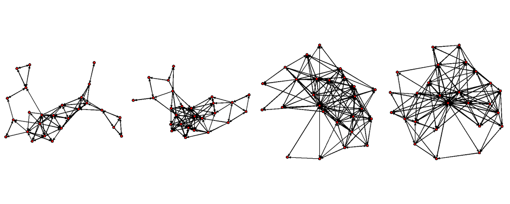

```r
par(mar = c(0, 0, 0, 0))
par(mfrow = c(1, 4))
plot(network(friendship[[1]]))
plot(network(friendship[[2]]))
plot(network(friendship[[3]]))
plot(network(friendship[[4]]))
```

**`primary`** is a 26 $\times$ 26 matrix indicating whether two pupils attended the same primary school. $0 =$ no, $1 =$ yes.

```r
str(primary)
```

```
##  int [1:26, 1:26] 0 0 0 0 0 0 0 0 0 0 ...
##  - attr(*, "dimnames")=List of 2
##   ..$ : NULL
##   ..$ : NULL
```

**`demographics`** is a data frame with 26 rows (the pupils) and four demographic variables about the pupils:

- `sex` (1 = girl, 2 = boy)
- `age` (in years)
- `ethnicity` (1 = Dutch, 2 = other, 0 = missing)
- `religion` (1 = Christian, 2 = non-religious, 3 = non-Christian religion, 0 = missing)

```r
str(demographics)
```

```
## 'data.frame':    26 obs. of  4 variables:
##  $ sex      : int  1 1 1 2 2 1 1 1 1 1 ...
##  $ age      : int  12 12 12 12 12 12 12 13 12 12 ...
##  $ ethnicity: int  1 1 2 1 1 1 1 1 1 1 ...
##  $ religion : int  2 2 3 2 2 0 2 2 2 1 ...
```

```r
sex <- demographics$sex
```

```r
# cross-sectional ERGM
mod_ergm <- ergm(friendship[[1]] ~ edges + mutual)
# tergm, BUT IGNORES `NA` VALUES AND STRUCTURAL MISSINGS
mod_tergm1 <- btergm(friendship ~ edges + mutual)
```

```r
texreg::screenreg(list(mod_ergm, mod_tergm1),
                  custom.model.names = c("ergm", "tergm1"),
                  stars = c(0.05))
```

```
##
## =========================================
##                 ergm       tergm1
## -----------------------------------------
## edges             -2.71 *   -2.19 *
##                   (0.18)   [-2.54; -1.88]
## mutual             3.18 *    2.84 *
##                   (0.39)   [ 2.64;  3.05]
## -----------------------------------------
## AIC              459.33
## BIC              468.29
## Log Likelihood  -227.67
## Num. obs.                   16
## =========================================
## * p < 0.05 (or 0 outside the confidence interval).
```

# Dealing with missing data

`handleMissings` converts missing values to something else:

- `method = "fillmode"` converts to the modal value
- `method = "zero"` replaces NAs with 0s

```r
table(unlist(friendship) , useNA = "always")
```

```
##
##    0    1   10 <NA>
## 2065  461  102   76
```

```r
friend <- handleMissings(friendship, na = NA, method = "fillmode")
table(unlist(friend) , useNA = "always")
```

```
##
##    0    1   10 <NA>
## 2141  461  102    0
```

# Dealing with missing data

`handleMissings` converts missing values to something else:

- `method = "remove"` iteratively removes rows or columns with the largest amount of missing data until no missing data are left in the matrix

```r
friend <- handleMissings(friend, na = 10, method = "remove")
table(unlist(friend) , useNA = "always")
```

```
##
##    0    1 <NA>
## 2141  461    0
```

```r
# only 25 nodes left at t=3 and t=4, but we don't know which ones
sapply(friend, dim)
```

```
##      t1 t2 t3 t4
## [1,] 26 26 25 25
## [2,] 26 26 25 25
```

```r
# but it works for a simple model:
mod_tergm2 <- btergm(friend ~ edges + mutual + ttriple +
                       transitiveties + ctriple)
```

```r
summary(mod_tergm2)
```

```
##                Estimate    2.5%   97.5%
## edges          -3.69293 -3.9523 -3.3851
## mutual          2.92674  2.4152  3.5837
## ttriple         0.48141  0.4299  0.5785
## transitiveties  0.45704  0.3125  0.5788
## ctriple        -0.96540 -1.2639 -0.7062
```

Complication 1: we want to use time-varying covariates, but their lengths differ now

Complication 2: constant covariate, but different dimensions at each time step

```r
for (i in 1:length(friendship)) {
  rownames(friendship[[i]]) <- 1:26
  colnames(friendship[[i]]) <- 1:26
}

friend <- handleMissings(friendship, na = NA, method = "fillmode")
friend <- handleMissings(friend, na = 10, method = "remove")
rownames(friend[[1]])[!(rownames(friend[[1]]) %in% rownames(friend[[4]]))]
```

```
## [1] "21"
```

```r
# node 21 dropped out
```

Complication 1: we want to use time-varying covariates, but their lengths differ now

Complication 2: constant covariate, but different dimensions at each time step

Complication 3: nodal covariates must be implemented in network object, but the length of the sex vector is still 26 while friendship sometimes has 25 nodes

`btergm` fixes these complications, automatically adjusting the dimensions between objects within a single time step:

- if a node is present in one network but not in another network at the same time step, the node is automatically removed from the first network to ensure compatibility.
- To make this adjustment work, however, row and column names must be consistently present

```r
# ADD ROW AND COLUMN NAMES TO COVARIATES
rownames(primary) <- rownames(friendship[[1]])
colnames(primary) <- colnames(friendship[[1]])
names(sex) <- 1:length(sex)
```

`btergm` fixes these complications, automatically adjusting the dimensions between objects within a single time step:

- if a node is present in one network but not in another network at the same time step, the node is automatically removed from the first network to ensure compatibility.
- To make this adjustment work, however, row and column names must be consistently present

```r
# ADD OTHER STATS FOR MODEL
for (i in 1:length(friend)) {
  s <- adjust(sex, friend[[i]])
  friend[[i]] <- network(friend[[i]])
  friend[[i]] <- set.vertex.attribute(friend[[i]], "sex", s)
  idegsqrt <- sqrt(degree(friend[[i]], cmode = "indegree"))
  friend[[i]] <- set.vertex.attribute(friend[[i]],
                                          "idegsqrt", idegsqrt)
  odegsqrt <- sqrt(degree(friend[[i]], cmode = "outdegree"))
  friend[[i]] <-
    set.vertex.attribute(friend[[i]], "odegsqrt", odegsqrt)
}

sapply(friend, network.size)
```

```
## t1 t2 t3 t4
## 26 26 25 25
```

```r
mod_tergm3 <- btergm(friend ~ edges + mutual + ttriple + transitiveties +
    ctriple + nodeicov("idegsqrt") + nodeicov("odegsqrt") +
    nodeocov("odegsqrt") + nodeofactor("sex") +
    nodeifactor("sex") + nodematch("sex") + edgecov(primary))
##
## Initial dimensions of the network and covariates:
##               t=1 t=2 t=3 t=4
## friend (row)   26  26  25  25
## friend (col)   26  26  25  25
## primary (row)  26  26  26  26
## primary (col)  26  26  26  26
##
## Dimensions differ across networks within time steps.
## Trying to auto-adjust the dimensions of the networks. If this fails, provide conformable matrices or network objects.
##
## Absent nodes:
##   label time   object where
## 1    21    3 networks   row
## 2    21    3 networks   col
## 3    21    4 networks   row
## 4    21    4 networks   col
##
## Number of nodes per time step after adjustment:
##                             t=1 t=2 t=3 t=4
## maximum deleted nodes (row)   0   0   1   1
## maximum deleted nodes (col)   0   0   1   1
## remaining rows               26  26  25  25
## remaining columns            26  26  25  25
##
## Dimensions of the network and covariates after adjustment:
##               t=1 t=2 t=3 t=4
## friend (row)   26  26  25  25
## friend (col)   26  26  25  25
## primary (row)  26  26  25  25
## primary (col)  26  26  25  25
##
## Starting pseudolikelihood estimation with 500 bootstrapping replications on a single computing core...
## Done.
```

```r
texreg::screenreg(mod_tergm3,  single.row = TRUE)
```

```
##
## ===============================================
##                       Model 1
## -----------------------------------------------
## edges                   -9.18 [-10.21; -8.69] *
## mutual                   2.96 [  2.39;  3.84] *
## ttriple                  0.21 [  0.12;  0.37] *
## transitiveties           0.37 [  0.25;  0.42] *
## ctriple                 -0.68 [ -0.96; -0.49] *
## nodeicov.idegsqrt        1.18 [  1.00;  1.48] *
## nodeicov.odegsqrt       -0.28 [ -0.65; -0.17] *
## nodeocov.odegsqrt        1.20 [  1.16;  1.41] *
## nodeofactor.sex.2        0.61 [  0.43;  0.83] *
## nodeifactor.sex.2        0.23 [  0.08;  0.36] *
## nodematch.sex            1.77 [  1.56;  2.15] *
## edgecov.primary[[i]]     1.05 [  0.75;  1.39] *
## -----------------------------------------------
## Num. obs.             2174
## ===============================================
## * 0 outside the confidence interval
```

Adding temporal terms:

| Model Term | Arguments/Defaults | Substance |
| --- | --- | --- |
| `delrecip` | `mutuality = FALSE` | Delayed reciprocity or mutuality |
|  | `lag = 1` |  |
| `timecov` | `x = NULL` | Time trend or interaction with time |
|  | `minimum = 1` |  |
|  | `maximum = NULL` |  |
|  | `transform = function(t) 1` |  |
| `memory` | `type = "stability"` | Positive autoregression; dyadic stability;edge innovation or loss |
|  | `lag = 1` |  |

```r
mod_tergm4 <- btergm(friend ~ edges + mutual + ttriple + transitiveties +
    ctriple + nodeicov("idegsqrt") + nodeicov("odegsqrt") +
    nodeocov("odegsqrt") + nodeofactor("sex") +
    nodeifactor("sex") + nodematch("sex") + edgecov(primary) +
    delrecip + memory(type = "stability"))
##
## Initial dimensions of the network and covariates:
##                t=2 t=3 t=4
## friend (row)    26  25  25
## friend (col)    26  25  25
## primary (row)   26  26  26
## primary (col)   26  26  26
## delrecip (row)  26  26  25
## delrecip (col)  26  26  25
## memory (row)    26  26  25
## memory (col)    26  26  25
##
## Dimensions differ across networks within time steps.
## Trying to auto-adjust the dimensions of the networks. If this fails, provide conformable matrices or network objects.
##
## Absent nodes:
##   label time   object where
## 1    21    3 networks   row
## 2    21    3 networks   col
## 3    21    4 networks   row
## 4    21    4 networks   col
##
## Number of nodes per time step after adjustment:
##                             t=2 t=3 t=4
## maximum deleted nodes (row)   0   1   1
## maximum deleted nodes (col)   0   1   1
## remaining rows               26  25  25
## remaining columns            26  25  25
##
## Dimensions of the network and covariates after adjustment:
##                t=2 t=3 t=4
## friend (row)    26  25  25
## friend (col)    26  25  25
## primary (row)   26  25  25
## primary (col)   26  25  25
## delrecip (row)  26  25  25
## delrecip (col)  26  25  25
## memory (row)    26  25  25
## memory (col)    26  25  25
##
## Starting pseudolikelihood estimation with 500 bootstrapping replications on a single computing core...
## Done.
summary(mod_tergm4)
## ==========================
## Summary of model fit
## ==========================
##
## Formula:   friend ~ edges + mutual + ttriple + transitiveties + ctriple + nodeicov("idegsqrt") + nodeicov("odegsqrt") + nodeocov("odegsqrt") + nodeofactor("sex") + nodeifactor("sex") + nodematch("sex") + edgecov(primary) + delrecip + memory(type = "stability")
## Time steps: 3
## Bootstrapping sample size: 500
## Estimates and 95% confidence intervals:
##                       Estimate     2.5%    97.5%
## edges                 -9.54228 -12.4210  -8.7203
## mutual                 2.17294   1.8416   2.8489
## ttriple                0.13423   0.0345   0.2411
## transitiveties         0.31509   0.2884   0.3945
## ctriple               -0.55434  -0.8214  -0.4185
## nodeicov.idegsqrt      1.28064   1.1152   1.6191
## nodeicov.odegsqrt     -0.13179  -0.3148  -0.0238
## nodeocov.odegsqrt      1.49624   1.3781   2.0224
## nodeofactor.sex.2      0.52990   0.3846   0.8317
## nodeifactor.sex.2      0.28694  -0.1334   0.6005
## nodematch.sex          1.49245   1.3044   2.0275
## edgecov.primary[[i]]   0.42395  -0.2828   0.9817
## edgecov.delrecip[[i]]  0.67436   0.3309   1.5025
## edgecov.memory[[i]]    0.77922   0.6761   1.0279
```

```r
texreg::screenreg(mod_tergm4,  single.row = TRUE)
```

```
##
## ================================================
##                        Model 1
## ------------------------------------------------
## edges                    -9.54 [-12.42; -8.72] *
## mutual                    2.17 [  1.84;  2.85] *
## ttriple                   0.13 [  0.03;  0.24] *
## transitiveties            0.32 [  0.29;  0.39] *
## ctriple                  -0.55 [ -0.82; -0.42] *
## nodeicov.idegsqrt         1.28 [  1.12;  1.62] *
## nodeicov.odegsqrt        -0.13 [ -0.31; -0.02] *
## nodeocov.odegsqrt         1.50 [  1.38;  2.02] *
## nodeofactor.sex.2         0.53 [  0.38;  0.83] *
## nodeifactor.sex.2         0.29 [ -0.13;  0.60]
## nodematch.sex             1.49 [  1.30;  2.03] *
## edgecov.primary[[i]]      0.42 [ -0.28;  0.98]
## edgecov.delrecip[[i]]     0.67 [  0.33;  1.50] *
## edgecov.memory[[i]]       0.78 [  0.68;  1.03] *
## ------------------------------------------------
## Num. obs.              1715
## ================================================
## * 0 outside the confidence interval
```

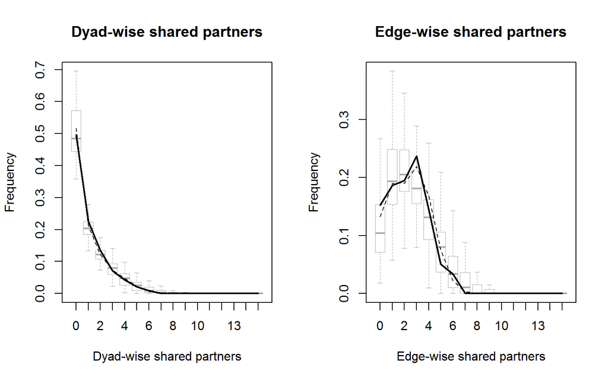

```r
gof_mod4 <- gof(mod_tergm4)

par(mfrow = c(1, 2))
plot(gof_mod4[[1]])
plot(gof_mod4[[2]])
```

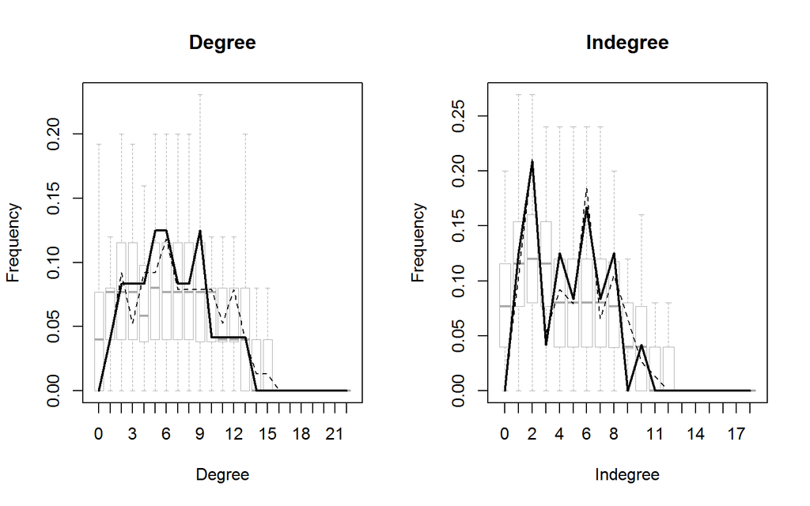

```r
par(mfrow = c(1, 2))
plot(gof_mod4[[3]])
plot(gof_mod4[[4]])
```

# The TNAM

```r
rm(list = ls())
library("tnam")
data("knecht")

head(delinquency)
```

```
##      t1 t2 t3 t4
## [1,]  2  2  3  5
## [2,]  1  0  1  2
## [3,]  2  2  1  4
## [4,]  2  2  3  2
## [5,]  1  1  2  1
## [6,]  1  1  1  1
```

# prepare the outcome variable and network

```r
delinquency <- as.data.frame(delinquency)
rownames(delinquency) <- letters

# replace 0s with NA
delinquency[delinquency == 0] <- NA

# replace structural zeros (denoted as 10)
friendship[[3]][friendship[[3]] == 10] <- NA
friendship[[4]][friendship[[4]] == 10] <- NA

# add row labels
for (i in 1:length(friendship)) {
  rownames(friendship[[i]]) <- letters
}
```

# Clean the covariates

```r
female <- ifelse(demographics$sex == 1, 1, 0)
names(female) <- letters


religion <- ifelse(demographics$religion == 0, NA, demographics$religion)
names(religion) <- letters

christian <- ifelse(religion == 1, 1, 0)
other_religion <- ifelse(religion == 3, 1, 0)
```

# Turn covariate vectors into lists

```r
female_list <- list(t1 = female,
               t2 = female,
               t3 = female,
               t4 = female)


christian_list <- list(t1 = christian,
                       t2 = christian,
                       t3 = christian,
                       t4 = christian)

other_religion_list <- list(t1 = other_religion,
                            t2 = other_religion,
                            t3 = other_religion,
                            t4 = other_religion)
```

# Estimate the model

```r
mod_tnam <- tnam(
  delinquency ~
    # EXOGENOUS COVARIATES
    covariate(female_list, coefname = "female") +
    covariate(christian_list, coefname = "christian") +
    # TIME LAG OF Y
    covariate(delinquency, lag = 1, exponent = 1) +
    # SPATIAL LAG OF Y: FRIEND'S DELINQUENCY
    netlag(delinquency, friendship) +
    # SPATIAL LAG OF Y: FRIEND'S OF FRIEND's DELINQUENCY
    netlag(delinquency, friendship, pathdist = 2, decay = 1) +
    netlag(delinquency, friendship, lag = 1) +
    # TRANSITIVITY
    clustering(friendship, directed = TRUE) +
    # CENTRALITY
    centrality(friendship, type = "betweenness"),
    # VARYING INTERCEPT FOR NODE AND LINEAR TIME TREND
    re.node = TRUE, time.linear = TRUE
)
```

```r
summary(mod_tnam)
```

```
## Linear mixed model fit by REML ['lmerMod']
## Formula: response ~ . - node + (1 | node)
##    Data: dat
##
## REML criterion at convergence: 170.1
##
## Scaled residuals:
##     Min      1Q  Median      3Q     Max
## -1.8494 -0.5833 -0.1511  0.6164  2.0695
##
## Random effects:
##  Groups   Name        Variance Std.Dev.
##  node     (Intercept) 0.0211   0.1452
##  Residual             0.5485   0.7406
## Number of obs: 63, groups:  node, 22
##
## Fixed effects:
##                        Estimate Std. Error t value
## (Intercept)            0.816000   0.480172   1.699
## time                   0.234510   0.151706   1.546
## covariate.female       0.062062   0.238118   0.261
## covariate.christian   -0.310225   0.310517  -0.999
## covariate.lag1         0.240851   0.138540   1.738
## netlag.pathdist1       0.036929   0.019551   1.889
## netlag.pathdist2      -0.021695   0.014783  -1.468
## netlag.lag1.pathdist1 -0.023595   0.017183  -1.373
## clustering             1.324540   0.630296   2.102
## betweenness           -0.010186   0.005268  -1.934
##
## Correlation of Fixed Effects:
##             (Intr) time   cvrt.f cvrt.c cvrt.1 ntlg.1 ntlg.2 nt.1.1 clstrn
## time        -0.342
## covarit.fml -0.259 -0.245
## cvrt.chrstn -0.198  0.047 -0.380
## covarit.lg1 -0.361 -0.307  0.092  0.192
## ntlg.pthds1 -0.063 -0.201  0.138  0.063  0.056
## ntlg.pthds2 -0.160 -0.470  0.239 -0.247  0.175 -0.113
## ntlg.lg1.p1 -0.031 -0.184  0.116  0.103 -0.068 -0.111 -0.175
## clustering  -0.439 -0.183 -0.023  0.274  0.009  0.087  0.211  0.068
## betweenness -0.275  0.088  0.005  0.025  0.053 -0.590  0.097  0.063  0.180
```

# ASSIGNMENT 7

Write a draft of the “Data” section of your final paper:

- Describe the data you will be working with
- Justify why the data are appropriate for testing your theory
- Provide descriptive statistics of important nodal attributes and network structure
- And, of course, provide a sociogram or sociograms of your network
  - make sure the sociogram is formatted to help readers see the most important features of the network